# Reproducible Research: Peer Assessment 1

## Introduction

It is now possible to collect a large amount of data about personal movement using activity monitoring devices such as a [Fitbit](http://www.fitbit.com), [Nike Fuelband](http://www.nike.com/us/en_us/c/nikeplus-fuelband), or [Jawbone Up](https://jawbone.com/up). These type of devices are part of the “quantified self” movement – a group of enthusiasts who take measurements about themselves regularly to improve their health, to find patterns in their behavior, or because they are tech geeks. But these data remain under-utilized both because the raw data are hard to obtain and there is a lack of statistical methods and software for processing and interpreting the data.

This assignment makes use of data from a personal activity monitoring device. This device collects data at 5 minute intervals through out the day. The data consists of two months of data from an anonymous individual collected during the months of October and November, 2012 and include the number of steps taken in 5 minute intervals each day.

## Data

The data for this assignment can be downloaded from the course web site:

- Dataset: [Activity monitoring data](https://d396qusza40orc.cloudfront.net/repdata%2Fdata%2Factivity.zip) [52K]

The variables included in this dataset are:

- **steps**: Number of steps taking in a 5-minute interval (missing values are coded as `NA`)
- **date**: The date on which the measurement was taken in YYYY-MM-DD format
- **interval**: Identifier for the 5-minute interval in which measurement was taken

The dataset is stored in a comma-separated-value (CSV) file and there are a total of 17,568 observations in this dataset.

## Assignment

### Loading and preprocessing the data

Show any code that is needed to

1. Load the data

`r filename <- "activity.csv" activity_df <- read.csv(filename, stringsAsFactors = FALSE)`

2. No additional processing/transforming of the data was done at this time

`r library(dplyr)`

`r library(ggplot2)`

### What is mean total number of steps taken per day?

For this part of the assignment, the missing values in the dataset were ignored

1. This is a histogram of the total number of steps taken each day

`r sum_steps_per_day <- activity_df %>% group_by(date) %>% filter(!is.na(steps)) %>% summarise(sum_per_day = sum(steps, rm.na = TRUE)) bins <- seq(from=min(sum_steps_per_day$sum_per_day), to=max(sum_steps_per_day$sum_per_day + 1000), by=1000) hist(sum_steps_per_day$sum_per_day, breaks=bins, xlab="Number of Steps", col = "red", main="Steps per Day")`

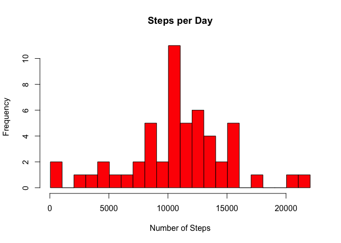

2. This is the **mean** and **median** respectively for the total number of steps taken per day

`r mean(sum_steps_per_day$sum_per_day)`

`## [1] 10767.19`

`r median(sum_steps_per_day$sum_per_day)`

`## [1] 10766`

### What is the average daily activity pattern?

1. This is a time series plot of the 5-minute interval (x-axis) and the average number of steps taken, averaged across all days (y-axis)

`r mean_steps_per_int <- activity_df %>% group_by(interval) %>% filter(!is.na(steps)) %>% summarise(mean_per_int = mean(steps)) mean_steps_per_int$Time <- sprintf("%02d:%02d", mean_steps_per_int$interval %/% 100, mean_steps_per_int$interval %% 100) c <- ggplot(mean_steps_per_int, aes(group = 1, y = mean_per_int, x = Time)) c <- c + geom_point(size = 1.5) + geom_line(col = "red") c + labs(y="Mean Steps per Interval", title="Average Daily Activity Pattern")`

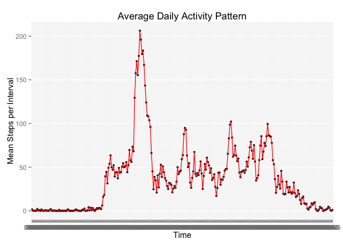

`r mean_steps_per_int$Time[max(mean_steps_per_int$mean_per_int)]`

`## [1] "17:05"`

### Imputing missing values

There are a number of days/intervals where there are missing values (coded as `NA`). The presence of missing days may introduce bias into some calculations or summaries of the data.

1. This is the total number of missing values in the dataset (i.e. the total number of rows with `NA`s)

`r nrow(count_of_NA <- activity_df %>% filter(is.na(steps)))`

`## [1] 2304`

2. The strategy for filling in all of the missing values in the dataset was to replace then with mean for that 5-minute interval.
3. This new dataset is equal to the original dataset but with the missing data filled in.

`r while (nrow(count_of_NA <- activity_df %>% filter(is.na(steps))) != 0) { activity_df$steps[which(is.na(activity_df$steps))] <- mean_steps_per_int$mean_per_int[ mean_steps_per_int$interval == activity_df$interval[which(is.na(activity_df$steps))]] } activity_df$steps <- round(activity_df$steps)`

`r sum_steps_per_day <- activity_df %>% group_by(date) %>% filter(!is.na(steps)) %>% summarise(sum_per_day = sum(steps, rm.na = TRUE)) bins <- seq(from=min(sum_steps_per_day$sum_per_day), to=max(sum_steps_per_day$sum_per_day + 1000), by=1000) hist(sum_steps_per_day$sum_per_day, breaks=bins, xlab="Number of Steps", col = "red", main="Steps per Day")`

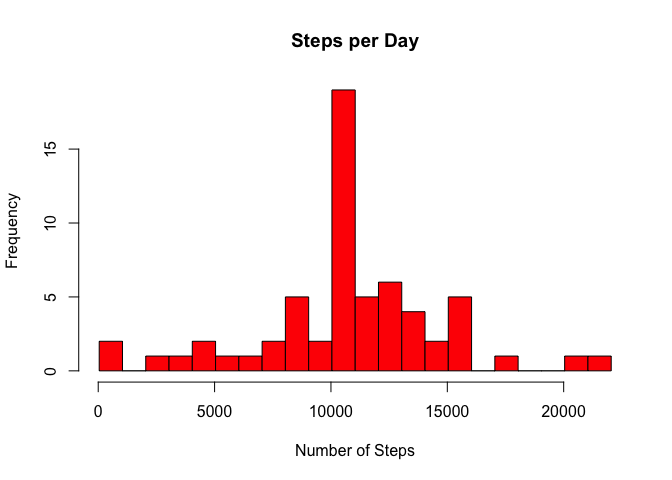

5. This is the **mean** and **median** respectively of ther total number of steps taken per day.

`r mean(sum_steps_per_day$sum_per_day)`

`## [1] 10766.64`

`r median(sum_steps_per_day$sum_per_day)`

`## [1] 10763`

Not done at this time